REVIEW ARTICLE

Platelet-rich plasma for the treatment of bone

defects: from pre-clinical rational to evidence in the clinical

practice. A systematic review

Alice Roffi<sup>1</sup>& Berardo Di Matteo<sup>1,2</sup>& Gopal Shankar Krishnakumar<sup>1</sup>& Elizaveta Kon<sup>1</sup>&

Giuseppe Filardo<sup>3</sup>

Received: 31 October 2016 /Accepted: 7 November 2016 /Published online: 26 November 2016

# The Author(s) 2016. This article is published with open access at Springerlink.com

Abstract

Purpose The treatment of large bone defects represents a sig-

nificant challenge for orthopaedic surgeons. In recent years,

biologic agents have also been used to further improve bone

healing. Among these, platelet-rich plasma (PRP) is the most

exploited strategy. The aim of the present study was to sys-

tematically review the available literature to identify: 1) pre-

clinical in-vivo results supporting the rational of PRP use for

bone healing; 2) evidence from the clinical practice on the

actual clinical benefit of PRP for the treatment of fractures

and complications such as delayed unions and non-unions.

Methods A systematic review of the literature was performed

on the application of PRP in bone healing, using the following

inclusion criteria: pre-clinical and clinical reports of any level

of evidence, written in English language, published in the last

20 years (1996–2016), on the use of PRP to stimulate long-

bone defect treatment, with focus on fracture and delayed/

non-unions healing.

Results The search in the Pubmed database identified 64 arti-

cles eligible for inclusion: 45 were preclinical in-vivo studies

and 19 were clinical studies. Despite the fact that the overall

pre-clinical results seem to support the benefit of PRP in

91.1 % of the studies, a more in depth analysis underlined a

lower success rate, with a positive outcome of 84.4 % in terms

of histological analysis, and even lower values considering

radiological and biomechanical results (75.0 % and 72.7 %

positive outcome respectively). This was also mirrored in the

clinical literature, where the real benefit of PRP use to treat

fractures and non-unions is still under debate.

Conclusion Overall, the available literature presents major

limitations in terms of low quality and extreme heterogeneity,

which hamper the possibility to optimize PRP treatment and

translate it into a real clinical benefit despite positive preclin-

ical findings on its biological potential to favour bone healing.

Keywords Bone defect <sup>.</sup>Bone healing <sup>.</sup>Fracture <sup>.</sup>Growth

factors <sup>.</sup>Non-union <sup>.</sup>PRP

Introduction

The treatment of large bone defects represents a significant clin-

ical challenge for orthopaedic surgeons [1, 2]. The well-

orchestrated regenerative ability of bone to heal is hampered,

in the case of complex defects, by the lack of a template for

regeneration and, eventually, it requires surgical intervention

[3]. Autografts and allografts are considered to be the major

bone substitutes, however they each have their own limitations

regarding availability, donor site morbidity and chronic pain,

leading to not always optimal results [4]. In order to overcome

these issues, several bone substitute materials have been devel-

oped and applied in the clinical practice [5, 6]. To further im-

prove the success rates, co-adjuvant agents have also been pro-

posed, which may enhance implant osseointegration potential

and restore bone tissue function [7]. Among these, growth fac-

tors (GFs) are expressed during different phases of tissue healing

and may represent a key element in promoting tissue regenera-

tion [8]. In fact, GFs delivered through orthopaedic devices have

* Berardo Di Matteo

berardo.dimatteo@gmail.com

1

Nano-Biotechnology Laboratory, Rizzoli Orthopaedic Institute, Via

di Barbiano 1/10, 40136 Bologna, Italy

2

I Orthopaedic and Traumatologic Clinic, Rizzoli Orthopaedic

Institute, Via Pupilli 1, 40136 Bologna, Italy

3

Biomechanics Laboratory, Rizzoli Orthopaedic Institute, Via di

Barbiano 1/10, 40136 Bologna, Italy

International Orthopaedics (SICOT) (2017) 41:221–237

DOI 10.1007/s00264-016-3342-9

been reported to enhance osteoblastic activity and favour im-

plant integration [9, 10].

Platelet-rich plasma (PRP) is emerging as a powerful tool for

tissue healing, thanks to the many GFs contained in

platelet alpha-granules. PRP is defined as a blood derivative,

where the platelets concentration is above the baseline levels,

thus providing a large number of bioactive molecules in physio-

logic proportions [11]. Activated platelets can release more than

300 molecules that are responsible for the coordination of nu-

merous cell-cell and cell-extracellular matrix (ECM) interactions

[12]. The evidence for PRP osteogenic potential has been sug-

gested by several in vitro studies, i.e. PRP addition in culture

medium promoted the proliferation and differentiation of human

mesenchymal stem cells (MSCs) [13, 14], and the effect of PRP

on osteogenic differentiation was also seen on human adipose

derived stem cells (ADSCs) [15]. Furthermore, PRP can improve

cell chemokinesis and chemotaxis through cytoskeleton reorga-

nization and accelerate cell migration, thus influencing osteoblast

like cells mobility [16]. Finally, anti-microbial effects have been

suggested [17, 18], which are highly desirable in relation to a

surgical bone application. However, besides the beneficial role in

terms of proliferation and differentiation, as well as cell migration

and protection towards microbial contamination, in-vitro studies

have also shown controversial results on PRP potential to favour

bone healing [19–21].

Thus, the aim of this study was to systematically review the

available literature to identify both preclinical in-vivo results

supporting the rational of PRP use for bone healing, and the

evidence from the orthopaedics practice on the actual clinical

benefit of PRP for the treatment of bone disorders.

Materials and methods

A systematic review of the literature was performed on the use

of PRP in both pre-clinical in-vivo setting and clinical setting

for the treatment of fractures and delayed unions/non-unions.

The search was conducted on the PubMed database on August

1st, 2016 using the following string: (PRP OR platelet-rich

plasma OR plasma rich in growth factors OR platelet derived

growth factor OR platelet derived OR platelet gel OR platelet

concentrate OR PRF OR platelet rich fibrin OR platelet rich

membrane OR ACP OR autologous conditioned plasma OR

PRGF OR platelet lysate) AND (fracture OR trauma OR trau-

matic OR non union OR mal union OR post-traumatic OR

pseudoarthrosis OR delayed union OR bone defect).

The screening process and analysis were conducted separately

by two independent observers (BDM and GS). First, the articles

were screened by title and abstract, using the following inclusion

criteria: pre-clinical and clinical reports of any level of evidence,

written in English language, published in the last 20 years (1996–

2016), on the use of PRP to stimulate long-bone defect treatment,

with focus on fracture and delayed/non-unions healing.

Exclusion criteria were articles written in other languages, re-

views, case reports or case series with less than ten patients

included, or studies analysing other applications of PRP in bone

pathology. In the second step, the full texts of the selected articles

were screened, with further exclusions according to the previous-

ly described criteria. Reference lists from the selected papers

collected, with the consensus of the two observers, in a database

including pertinent information (type of study, number of cases,

follow-up, PRP preparation, cytology and application modality,

type of surgical treatment or animal model used, type of bone or

other materials applied, type of evaluation and results) to be

analysed for the purposes of the present manuscript.

Results

In total 3160 articles were screened and 64 articles were found

to be eligible for inclusion in the present review. Among these,

45 were pre-clinical in-vivo studies [1, 2, 4, 22–63] and 19

in Fig. 2. Results will be discussed separately for pre-clinical

and clinical studies.

Pre-clinical studies

Animal models

Of the 45 identified studies (Table 1), 20 (44.4 %) used a

rabbit model, while other animals were used in a smaller num-

ber of studies, i.e. rat in eight studies (17.8 %), sheep in seven

studies (15.6 %), dog in four studies (8.9 %), pig in four

studies (8.9 %) and goat in two studies (4.4 %). With regard

to defect type, bone sites were tibia in 16 studies (35.6 %)

tures), radius in ten studies (22.2 %) (nine segmental, one

fracture), fibula in 1 study (2.2 %) (one fracture), ulna in three

studies (6.7 %) (three segmental defects) and metatarsus in

one study (2.2 %) (one segmental defects).

With regard to the delivery mode, 3/45 studies delivered

PRP through percutaneous injection while the remaining stud-

ies used the surgical approach to apply PRP either alone or in

combination with other materials. Only one paper described

the combination of percutaneous PRP injection and surgical

PRP delivery with biomaterial. Besides seven articles (16 %)

documenting the effect of PRP alone, most of the studies (38

papers, 84 %) analysed the effect of PRP with other materials:

20 studies (53 %) reported the use of three dimensional scaf-

folds, nine (23.5 %) with auto (n = 5) / allo (n = 3) / xenografts

(n = 1) and nine (23.5 %) with powders/granules/pastes.

Finally, with regard to other biological augmentations, 11 pa-

pers (24.4 %) reported the use of MSCs as a co-adjuvant

osteogenic factor in their studies. BMSCs was the favourite

cell source, used in eight papers, followed by bone marrow

concentrate (BMC) in two articles, and BMSCs vs. ADSCs

were reported in one article.

PRP preparation

Platelet count was reported in studies 32/45 (71 %) with het-

erogeneous platelet concentration. However, all showed sig-

nificantly higher levels of platelets than in whole peripheral

blood, ranging from 1.1 x to 10.1 x. Sixteen out of 45 papers

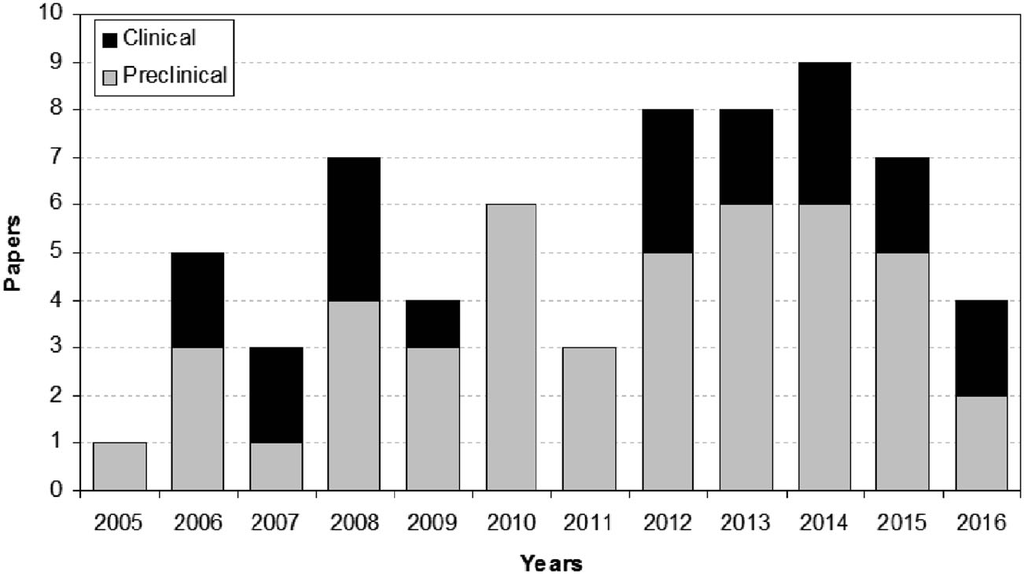

Fig. 2 Pre-clinical and clinical

studies published over time

Table 1

Complete details of 45 pre-clinical papers identified in this systematic review

Publication

Treatment groups

PRP characteristics

Animal model

Protocol

Effects

Scaffold

1. Hokugo et al.

2005 [22]

1) Gelatin

2) Gelatin + PRP

3) Fibrin-glue + PRP

4) PRP

5) Control (untreated)

Platelet concentration: NA

Activation: NA

Leukocytes: NA

Allogenic

Fresh/frozen: NA

GFs: TGF-β1 and PDGF-BB

Rabbit ulna segmental defect

(10 mm)

Hist: +

X-Ray: +

DEXA: +

Positive results for PRP in combination

with gelatin

+

2. Sugimori et al.

2006 [23]

1) AF

2) PRP

3) AF + PRP

4) Control (untreated)

Platelet concentration: 2.5 x

Activation: NA

Leukocytes: NA

Allogenic

Fresh/frozen: NA

GFs: NA

Rat tibial cylindrical defect

(3.5 mm x 4.5 mm)

Hist: +

Positive results for PRP in combination

with AF

+

3. Sarkar et al.

2006 [4]

1) Collagen + PRP

2) Collagen

Platelet concentration: 3.5 x

Activation: NA

Leukocytes: yes

Autologous

Fresh

GFs: NA

Sheep tibial segmental defect

(25 mm)

Hist: =

X-Ray: =

μCT: =

Mech: =

=

4. Rai et al.

2007 [24]

1) PCL/TCP

2) PCL/TCP + PRP

Platelet concentration: NA

Activation: calcium chloride\thrombin

Leukocytes: NA

Allogenic

Fresh

GFs: NA

Rat femoral segmental defect

(8 mm)

Hist: =

X-Ray: +

μCT: +

Mech: +

+

5. Kasten et al.

2008 [25]

1) CDHA + BMSCs

2) CDHA + PRP

3) CDHA + PRP + BMSCs

4) CDHA

5) ABG

6) Control (untreated)

Platelet concentration: 5.3 x

Activation: calcium chloride\thrombin

Leukocytes: NA

Allogenic

Frozen

GFs: NA

Rabbit radius segmental defect

(15 mm)

Hist: +

X-Ray: +

μCT: +

Mech: +

+

6. Lysiak-Drwal et al.

2008 [26]

1) BOC + BG

2) BOC + BG + PRP

3) Control (untreated)

Platelet concentration: NA

Activation: NA

Leukocytes: yes

Allogenic/autologous: NA

Fresh/frozen: NA

GFs: NA

Rabbit femoral cylindrical

defect

(5 mm)

Hist: +

+

7. Nair et al.

2009 [1]

1) HASi

2) HASi + BMSCs

3) HASi + BMSCs + PRP

Platelet concentration: 1.5 x

Activation: NA

Leukocytes: NA

Autologous

Fresh

GFs: NA

Goat femoral segmental defect

(20 mm)

Hist: +

X-Ray: +

+

8. Niemeyer et al.

2010 [27]

1) HA/collagen + BMSCs

2) HA/collagen + ASCs

3) HA/collagen + ASCs + PRP

4) Control (untreated)

Platelet concentration: 4.5 x

Activation: calcium chloride/thrombin

Leukocytes: No

Xenogenic

Frozen

GFs: PDGF-AB and TGF-β1

Sheep tibial segmental defect

(30 mm)

Hist: +

X-Ray: +

+

9. Bi et al.

2010 [28]

1) TCP/chitosan

2) TCP/chitosan + PRP

3) Control (untreated)

Platelet concentration: 5.3 x

Activation: calcium chloride\thrombin

Leukocytes: NA

Allogenic/autologous: NA

Fresh/frozen: NA

Goat tibia cylindrical defect

(12 mm)

Hist: +

X-Ray: +

+

Table 1 (continued)

Publication

Treatment groups

PRP characteristics

Animal model

Protocol

Effects

GFs: TGF-β1, PDGF-BB, bFGF and VEGF

10. Kon et al.

2010 [29]

1) COL/HA

2) COL/HA + PRP

3) Control (untreated)

Platelet concentration: 3.2 x

Activation: calcium chloride

Leukocytes: yes

Autologous

Fresh

GFs: TGF-β1, PDGF-AB and IL1

Sheep femoral condyle

cylindrical defect

(7 mm x 9 mm)

Hist: −

X-Ray: −

-

11. Kanthan et al.

2011 [30]

1) PRP

2) Coral

3) Coral + PRP

4) Control (untreated)

Platelet concentration: 2.6 - 4.6 x

Activation: calcium chloride/thrombin

Leukocytes: NA

Autologous

Fresh

GFs: NA

Rabbit tibial segmental defect

(20 mm)

Hist: +

X-Ray: +

+

12. Zhang et al.

2011 [31]

1) Bioactive glass

2) Bioactive glass + PRP

3) Control (untreated)

Platelet concentration: NA

Activation: calcium chloride/thrombin

Leukocytes: NA

Allogenic/autologous: NA

Fresh/frozen: NA

GFs: NA

Rabbit radius segmental defect

(15 mm)

Hist: +

X-Ray: +

μCT: +

+

13. Parizi et al.

2012 [32]

1) Coral

2) Coral + PRP +1 injection 4 days post op

3) Control (untreated)

Platelet concentration: 10.1 x

Activation: NA

Leukocytes: no

Xenogenic

Frozen

GFs: NA

Rabbit radius segmental defect

(10 mm)

Hist: +

X-Ray: +

Mech: +

+

14. Oryan et al.

2012 [33]

1) HA

2) HA + hPRP

3) Control (untreated)

Platelet concentration: 10.1 x

Activation: NA

Leukocytes: No

Xenogenic

Frozen

GFs: NA

Rabbit radius segmental defect

(10 mm)

Hist: +

X-Ray: +

Mech: =

+

15. Kasten et al.

2012 [34]

1) CDHA

2) CDHA + PRP

3) CDHA + PRP + BMSCs

4) CDHA + BMSCs

5) CDHA + BMSCs +

VEGF (transfected)

Platelet concentration: 5.3 x

Activation: calcium chloride/ thrombin

Leukocytes: NA

Allogenic

Frozen

GFs: NA

Rabbit radius segmental defect

(15 mm)

Hist: +

μCT: +

+

16. Kim et al.

2014 [35]

1) Gelatin + PRP

2) Gelatin + SEW2871 micelles

3) Gelatin + SEW2871 micelles + PRP

4) Control (untreated)

Platelet concentration: 8–10 x

Activation: calcium chloride

Leukocytes: NA

Allogenic

Fresh/frozen: NA

GFs: TGF-β1 and SDF-1

Rat ulnar segmental defect

(6 mm)

Hist: +

X-Ray: +

μCT: +

+

17. Filardo et al.

2014 [36]

1) BioSiC(HaCol)

2) BioSiC (HaCol) + PRP

3) BioSiC (HaCol) + BMSCs

Platelet concentration: 2.8 x

Activation: calcium chloride

Leukocytes: yes

Autologous

Fresh

GFs: NA

Sheep metatarsus segmental defect

(20 mm)

Hist: +

X-Ray: =

+

18. Zhong et al.

2014 [37]

1) β-TCP + BMSCs

2) β-TCP + BMSCs

+ PRP

3) Autogenic ilium (control)

Platelet concentration: NA

Activation: calcium chloride/thrombin

Leukocytes: NA

Autologous

Dog tibia cylindrical defect

(10 mm)

Hist: +

X-Ray: +

Mech: +

+

Table 1 (continued)

Publication

Treatment groups

PRP characteristics

Animal model

Protocol

Effects

Frozen

GFs: NA

19. He et al.

2015 [2]

1) PLGA/CPC

2) PLGA/CPC + PRP

Platelet concentration: 3.3 x

Activation: calcium chloride/ thrombin

Leukocytes: yes

Allogenic

Fresh/frozen: NA

GFs: NA

Rabbit femoral cylindrical defect

(6 mm x 10 mm)

Rabbit radius segmental defect

(15 mm)

In femoral defect:

Hist: +

X-Ray: +

μCT: +

In radial defect:

Hist: +

X-Ray: +

μCT: +

+

20. Chen et al.

2016 [38]

1) CS + PRP

2) CS

3) PRP

4) BMP-2 (positive control)

Platelet concentration: 8–10 x

Activation: calcium chloride/thrombin

Leukocytes: NA

Autologous

Fresh

GFs: NA

Rabbit radius segmental defect

(12 mm)

Hist: +

X-Ray: +

: +

Superior results for CS + PRP with

respect to CS and PRP alone, but

similar results with BMP-2

+

Autograft/

allograft/

xenograft

21. Dallari et al.

2006 [39]

1) BMSCs + PRP

2) FDBA + BMSCs

3) FDBA + PRP

4) FDBA + PRP + BMSCs

Platelet concentration: 2.8 x

Activation: calcium chloride/thrombin

Leukocytes: yes

Autologous

Fresh

GFs: NA

Rabbit femoral cylindrical defect

(diameter: 6 mm; depth: 10 mm)

Hist: −

Superior results for FDBA + PRP +

BMSCs

+

22. Kroese-Deutman

et al.

2008 [40]

1) Ti

2) Ti-Bone chips

3) Ti-Bone chips + PRP

Platelet concentration: 1000–1500 x 109 / L

Activation: bovine thrombin

Leukocytes: NA

Autologous

Fresh

GFs: NA

Rabbit radial segmental defect

(15 mm)

Hist: +

X-Ray: =

+

23. Molina-Minano

et al.

2009 [41]

1) Autograft

2) PRP

3) Autograft + PRP

4) Control (untreated)

Platelet concentration: NA

Activation: calcium chloride

Leukocytes: NA

Allogenic

Fresh

GFs: NA

Rabbit tibial cylindrical defect

(4 mm)

Hist: =

X-Ray:

+ at 1 m

= at 2 m

+

24. Hakimi et al.

2010 [42]

1) Autograft

2) Autograft + PRP

Platelet concentration: 4.9 x

Activation: calcium chloride/thrombin

Leukocytes: yes

Autologous

Fresh

GFs: TGF-β1 and PDGF-BB

Pig tibial cylindrical defect

(11 x 25 mm)

Hist: +

X-Ray: =

+

25. Nather et al.

2012 [43]

1) Autograft

2) Allograft

3) Allograft + PRP

Platelet concentration: NA

Activation: thrombin

Leukocytes: NA

Autologous

Fresh

GFs: NA

Rabbit tibial segmental defect

(15 mm)

Hist:

+ at 12 w

= at 24 w

X-Ray:

= for all the aspects related to

mineralization and bone volume

+ for resorption index

+

26. Kurikchy et al.

2013 [44]

1) Xenograft

2) Xenograft + PRP

3) Control (untreated)

Platelet concentration: 2–3 x

Activation: calcium chloride

Leukocytes: NA

Autologous

Fresh

GFs: NA

Rabbit femoral cylindrical defect

(3 mm)

Hist: +

+

Table 1 (continued)

Publication

Treatment groups

PRP characteristics

Animal model

Protocol

Effects

27. Zhang et al.

2013 [45]

1) DPB + PRP + BMSCs

2) DPB + BMSCs

3) DPB + PRP

4) DPB

Platelet concentration: 4 x

Activation: calcium chloride\thrombin

Leukocytes: NA

Allogenic

Fresh/frozen: NA

GFs: TGF-β1, PDGF, EGF and VEGF

Rabbit radial segmental defect

(15 mm)

Hist: +

X-Ray: +

DEXA:

+ for new bone tissue quality

+

28. Schneppendahl et al.

2015 [46]

1) Autograft + PRP

2) Autograft

Platelet concentration: 5.4 x

Activation: calcium chloride/thrombin

Leukocytes: NA

Autologous

Fresh

GFs: TGF-β1; PDGF-BB; VEGF

Rabbit radial segmental defect

(15x4x3 mm)

Hist: +

X-Ray: +

+

29. Park et al.

2016 [47]

1) Synthetic bone

2) CGF

3) PRF

4) Control (untreated)

Platelet concentration: NA

Activation: NA

Leukocytes: NA

Autologous

Fresh

GFs: TGF-β and VEGF

Dog femur cylindrical defect

(8 mm)

Hist: +

+

Powder/granules 30. Rabillard et al.

2009 [48]

1) CaP

2) CaP + PRP

Platelet concentration: 3-6x

Activation: calcium Borogluconate +

batroxobin

Leukocytes: NA

Autologous

Fresh

GFs: NA

Dog ulnar segmental defect

(20 mm)

Hist: =

X-Ray: =

SEM: =

=

31. Jungbluth et al.

2010 [49]

1) CaP

2) CaP + PRP

Platelet concentration: 4.4 x

Activation: calcium chloride/ thrombin

Leukocytes: NA

Autogenous

Fresh

GFs: TGF-β1 and PDGF-BB

Pig tibial defect cylindrical defect

(11x25 mm)

Hist: +

X-Ray: +

+

32. Batista et al.

2011 [50]

1) β - TCP + PRP

2) β - TCP + BMCs

Platelet concentration: 6.2 x

Activation: calcium gluonate

Leukocytes: NA

Allogenic

Fresh

GFs: NA

Rabbit tibial cylindrical defect

(3.3 mm)

Hist: +

X-Ray: =

μCT: +

+

33. Bolukbasi et al.

2013 [51]

1) BCP

2) BCP + PRF

3) PRF

4) Control (untreated)

Platelet concentration: NA

Activation: no

Leukocytes: NA

Autologous

Fresh

GFs: NA

Sheep tibial cylindrical defect

(5 mm)

Hist: +

+

34. Hakimi et al.

2014 [52]

1) CPG

2) CPG + BMCs

3) CPG + BMCs + PRP

4) Autografts

Platelet concentration: 4.7 x

Activation: calcium chloride/thrombin

Leukocytes: yes

Autologous

Fresh

GFs: TGF-β1 and PDGF-BB

Pig tibial cylindrical defect

(25 x 11 mm)

Hist: +

X-Ray: +

μCT: +

X-Ray superior for CPG + BMSCs + PRP

compared to CPG alone and CPG +

BMSCs, but similar results compared

to autograft

+

35. Yilmaz et al.

2014 [53]

1) PRF

2) β-TCP

3) β-TCP + PRF

Platelet concentration: NA

Activation: no

Leukocytes: NA

Pig tibia cylindrical defect

(5 mm)

Hist: +

Superior results for β-TCP + PRF

+

Table 1 (continued)

Publication

Treatment groups

PRP characteristics

Animal model

Protocol

Effects

4) Control (untreated)

Autologous

Fresh

GFs: NA

36. Malhotra et al.

2014 [54]

1) BCP + 33 % PRP

2) BCP + 66 % PRP

3) BCP + 100 % PRP

4) Autografts

5) BCP

6) Control (untreated)

Platelet concentration: 2.9 x

Activation: calcium chloride/thrombin

Leukocytes: 0.6 x

Fibrinogen: 0.6 x

Autologous

Fresh

GFs: TGF-β1

Sheep femoral cylindrical defect

(11x20 mm)

Hist: +

X-Ray: +

μCT: +

Highest dose of PRP: greater micro-CT

bone volume compared with BCP

alone

All PRP doses: better histomorphometric

parameters vs BCP alone

+

37. Qi et al.

2015 [55]

1) BMSCs + PRP gel

2) CaP

3) CaP + PRP gel

4) CaP + BMSCs

5) CaP + BMSCs + PRP gel

6) Control (untreated)

Platelet concentration: 6 x

Activation: calcium chloride/ thrombin

Leukocytes:NA

Allogenic

Fresh/frozen: NA

GFs: NA

Rat femur cylindrical defect

(2.5 x 5 mm)

Hist: +

X-Ray: +

SEM:+

Superior results for CaP + BMSCs + PRP

gel

+

38. Velev et al.

2015 [56]

1) TCP cement

2) TCP cement + PRP

3) TCP cement + GH

Platelet concentration: NA

Activation: No

Leukocytes: No

Autologous

Fresh

GFs: NA

Rabbit tibia cylindrical defect

(6 mm)

Hist: + for qualitative analysis

= for quantitative analysis

+

PRP alone

39. Simman et al.

2008 [57]

1) PRP

2) Control (untreated)

Platelet concentration: 2.7 x

Activation: calcium chloride/thrombin

Leukocytes: NA

Allogenic

Fresh/frozen: NA

GFs: TGF-β1, P-selectin and BMP-2

Rat femoral fracture

Hist: +

X-Ray: +

Mech: =

+

40. Gumieiro et al.

2010 [58]

1) PRP

2) Control (untreated)

Platelet concentration: 4x

Activation: calcium chloride

Leukocytes: NA

Allogenic

Fresh

GFs: NA

Rat tibial cylindrical defect

(3 mm)

Hist: +

The effect of PRP is present more in the

first 14 days

+

41. Souza et al.

2012 [59]

1) PRP

2) Control (untreated)

Platelet concentration: 338 %

Activation: calcium chloride

Leukocytes: NA

Autologous

Fresh

GFs: NA

Dog radial fracture with 2 mm gap Hist: +

X-Ray: +

DEXA: +

Mech: +

+

42. Chen et al.

2013 [60]

1) High conc PRP

2) Medium conc PRP

3) Low conc PRP

4) PPP

5) Control (untreated)

Platelet concentration (high/medium/low)

Activation: calcium chloride/thrombin

Leukocytes: NA

Allogenic

Fresh/frozen: NA

GFs: TGF-β1 and PDGF-BB

Rat femoral fracture

Hist: +

X-Ray: +

Mech: +

Superior results for medium conc. of PRP

+

43. Neves et al.

2013 [61]

1) PRP

2) HBO

3) PRP+ HBO

4) Control (untreated)

Platelet concentration: 2x

Activation: No

Leukocytes: No

Autologous

Fresh

GFs: NA

Rabbit fibula segmental fracture

Hist: +

+

reported information about leukocytes content in PRP, nine of

which described the use of leukocyte-rich PRP and seven of

leukocyte-poor PRP. Only one paper out of 45 reported fibrin-

ogen content. Fourteen studies analysed PRP for GFs, which

included TGF-β1 (in 14), PDGF (in ten), VEGF (in four),

bFGF (in one), SDF-1 (in one), p-selectine (in one), BMP-2

(in one), IL-1 (in one) and EGF (in one).

Thirty-two out of 45 papers (71 %) reported information

about the use of fresh or frozen PRP: 26 were fresh and six

frozen; while 42 (93.3 %) papers reported the type of PRP in

terms of autologous (in 24), allogeneic (in 15), and xenoge-

neic (in three) origin. Finally, PRP activation modality was not

reported in 12 studies; among studies where this was specified

(33 papers, 73.3 %), 20 (60.6 %) reported a combination of

CaCl2 and thrombin, nine (27.3 %) used CaCl2 alone, two

(6.1 %) thrombin alone, one (3 %) calcium gluconate, one

(3 %) calcium borogluconate and one (3 %) batroxobin.

Pre-clinical findings

Overall positive results were shown in 41 studies (91 %),

while three studies (7 %) showed the same results as control

and one study (2 %) showed negative effects of PRP use. In

particular, among the 20 studies reporting the use of PRP with

scaffolds (hydroxyapatite alone or in combination with colla-

gen was the most frequent material used), 18 showed positive

results; among the nine papers using bone grafts, all reported

good results. Among the nine studies on PRP with powder/

granules, eight showed a good outcome. Finally, among the

seven studies where PRP was used alone, six reported good

results while one study using PRP injections failed to show

significant effects. Finally, the use of MSCs always provided a

benefit, with PRP further increasing the outcome in all 11

studies.

Further analyses have been performed according to the

results of each specific evaluation performed. The histological

outcome has been reported in 45 papers, with 38 (84.4 %)

showing significant improvement in bone healing. The radio-

graphic outcome was reported in 32/45 papers; among these

studies 24 (75.0 %) showed significant bone consolidation.

The micro-computed tomography (CT) outcome was reported

in 11 papers and significant bone area formation was reported

in nine (81.8 %) studies. DEXA analysis was reported only in

three studies, with good results in favour of PRP in all papers.

Finally, biomechanical tests in regard to torsion, torque and

cal properties.

Clinical studies

A total of 19 clinical trials were found to be eligible for inclu-

sion in the present review: nine dealt with fracture

Table 1 (continued)

Publication

Treatment groups

PRP characteristics

Animal model

Protocol

Effects

44. Hernandez –

Fernandez et al.

2013 [62]

1) PRP

2) Control (untreated)

Platelet concentration: 4.6 x

Activation: calcium chloride

Leukocytes: No

Autologous

Fresh/frozen: NA

GFs: NA

Sheep femur osteotomy model

Hist: =

μCT: =

=

45. Guzel et al.

2015 [63]

1) PRP

2) Control (untreated)

Platelet concentration: NA

Activation: calcium chloride

Leukocytes: No

Allogenic

Fresh/frozen: NA

GFs: NA

Rat femoral fracture

Hist: +

Mech: +

+

PRP Platelet- rich Plasma, AF Apatite foam, PCL/TCP Polycaprolactone-tricalcium phosphate, CDHA Calcium deficient hydroxyapatite, BOC + BG Bio-Oss Collagen + BioGide Perio membrane, HASi

Triphasic ceramic-coated hydroxypatite, HA Hydroxapatite, TCP Tri-calcium phospahte, COL/HA Collagen + Hydroxapatite, hPRP Human platelet rich plasma, BioSic Biomorphic silicon carbide, β-TCP

Beta-tricalcium phospahte, PLGA/CPC Poly (lactic-co-glycolic acid) + calcium phosphate cement, CS Calcium sulphate, FDBA Fried dried bone allograft, Ti Titanium, DPB Deproteinized bone matrix,

CGF Concentrated growth factor, PRF Platelet rich fibrin, CaP Calcium phospahte, BCP Biphasic calcium phosphate, CPG Calcium phosphate granules, BMSCs Bone marrow derived mesenchymal stem

cells, ASCs Adipose derived stem cells, BMCs Bone marrow concentrate, HBO Hyperbaric oxygen, TGF-β1 Transforming growth factor beta 1, PDGF-BB Platelet-derived growth factor, bFGF Basic

fibroblast growth factor, VEGF Vascular endothelial growth factor, IL-1 Interleukin-1, SDF-1 Stromal cell-derived factor 1, EGF Epidermal growth factor, BMP-2 Bone morphogenetic protein 2, Hist

Histology analysis, μCT Micro-computed tomography, DEXA Dual-energy x-ray absorptiometry, Mech Mechanical analysis, NA Not available

management [64–72] whereas ten focused on fracture compli-

cations [73–83] (i.e. delayed unions or non-unions; Table 2).

Treatment of fractures

Eight out of nine studies were RCTs and one was a retrospec-

tive comparative trial [64]. Three studies aimed at understand-

ing the role of PRP in stimulating healing after iatrogenic

fractures: two trials in opening-wedge high tibial osteotomy

(HTO) [65, 66] and one in tibial distraction osteogenesis for

limb lengthening [67]. The other six trials focused on dispa-

rate traumatic injuries: two papers on hip fractures [68, 69],

one paper on calcaneus fractures [70], one (the retrospective

comparative trial) on complex bimalleolar fractures [64], one

on tibial pilon fractures [71] and one on intra-articular distal

radial fractures [72]. With regard to the application strategies,

PRP was locally applied during surgery in eight studies,

whereas in one case a delayed PRP injection was applied

while in two papers authors did not provide specific details

about the PRP formulation adopted. In six trials PRP was

associated to other Baugmentation strategies^, such as MSCs

and/or bone graft (Table 2).

Overall, eight out of nine papers reported radiologic out-

comes: six of them revealed better results with PRP, one found

no difference, whereas one paper documented worse radiolog-

ic results with the biologic augmentation. Clinical outcomes

were reported in only five papers, i.e. functional subjective

scores and/or objective measurements and/or complications

after PRP treatment: in three cases PRP did not provide any

beneficial contribution, whereas in the remaining two studies

it contributed to a superior clinical outcome. Finally, only one

trial documented histomorphometric results, showing that the

addition of PRP to bone chips, even more if combined with

BMC augmentation, was able to promote a superior healing of

the high tibial osteotomy gap site (Table 2).

Treatment of delayed unions/non unions

Out of the ten studies (11 papers in total) on the application of

PRP to manage delayed unions or non-unions [73–83], four

used a minimally invasive approach through percutaneous

both treatment approaches (Table 2). Only one trial (which

was the object of two different publications, one reporting

the preliminary results and the other reporting the complete

data) was a RCT [73, 74], whereas all the others were case

series. In four studies PRP was used together with other aug-

mentation strategies (bone graft or synthetic bone). PRP was

leukocyte-rich in two studies and leukocyte-depleted in three

studies, while in five trials authors did not provide specific

details about the PRP formulation adopted (Table 2).

All but one [75] study considered patients affected by de-

layed union/non-union in different anatomical districts pooled

together (mainly humerus, femur and tibia, which are the most

common sites for this kind of complication), thus reducing the

homogeneity of the cohorts of patients. With regard to the

of non-union or delayed union) failed to documented a bene-

ficial effect of the biological stimulation [76, 77]. The other

reports suggested instead a positive role of PRP, although the

only RCT documented a clear advantage of bone

morphogeneic protein 7 (BMP-7) over PRP in stimulating

bone healing (Table 2) [73, 74].

Discussion

This systematic research of the literature documented a grow-

ing interest on PRP use for bone disorders, with an increasing

number of papers published over time which show a complex

scenery and more controversial results than previously

thought.

In fact, while basic science suggests several favourable

potential effects of PRP for bone healing, and platelet concen-

trates have also been successfully used in other medical fields

to enhance bone and soft tissue regeneration [5, 84–86], the

evidence on its real benefit is questionable. The first phase of

the literature analysis focused on preclinical in-vivo evidence,

which should allow us to understand potential and indications

for PRP use. This systematic review documented 45 papers

reporting heterogeneous models both in terms of animal mod-

el and defect type chosen. This is an important factor to con-

sider in terms of results transferability to the clinical field. In

fact, although several models are appropriate for the evalua-

tion of bone regeneration, not all of them closely reproduce

human tissue characteristics. Chosen models should present

physiological and pathophysiological analogies to favour re-

sults transferability: for this reason larger models more closely

resemble the human condition [87]. For example, pig models

present bone features similar to humans in terms of mineral

density, concentration and healing capacity, with a 1.2 to

1.5 mm per day growth rate, similar to bone regeneration

capacity in humans [88]. Among the studies found in this

systematic review, only four chose the pig model, while the

majority adopted smaller models with rabbits or even rats.

Moreover, these animal models analysed surgically-created

acute lesions which were treated immediately, oppositely to

what happens in the clinical practice. Despite the inherent

limits of these models in terms of transferability to humans,

these studies still showed overall promising findings, with a

positive outcome documented in 91.1 % of the papers.

However, a more in depth analysis shed some doubts on the

Table 2

Synopsis of clinical trials dealing with PRP application in fractures and non-union/delayed union management

Fractures

Publication

Study design

N of patients

Pathology

Therapeutic protocol

Platelet count

and leukocytes

Activation

F-up

Main findings

Namazi H et al., Orthop

Tramatol Surg

Res.2016 [72]

Randomized

controlled trial

30 patients:

n = 15 percutaneous fixation

+ PRP

n = 15 percutaneous fixation

Distal radius fracture

Intra-articular injection of

PRP immediately after

percutaneous pinning

fixation

Platelet count: NA

Leukocytes: no

no

6 months

PRP has significant effect on

reduction of pain and functional

recovery

Rodriguez-Collazo ER

et al., Strategies

Trauma Limb

Reconstr. 2015 [64]

Case series

20 patient with relevant

comorbidities

n = 10 BMC + PRP +

DBM+ EF

n =10 DBM+ EF (historical

controls)

Bimalleolar fractures

PRP and BMC mixed

with DBM and

injected locally at the

fracture site

Platelet count: NA

Leukocytes: yes

no

18 months

External fixation + DBM, BMA and

PRP promoted fracture healing of

the distal tibia and fibula in

patients with significant

co-morbidities

Samy AM

Int orthop. 2015 [68]

Randomized

controlled trial

60 patients:

n =30 screw fixation

n =30 screw fixation + PRP

Femoral neck fracture

PRP locally applied

during surgery

Platelet count: NA

Leukocytes: no

n.a.

48 months

PRP was a beneficial adjuvant to the

classical internal fixation

technique: both radiologic and

clinical outcome were better in

PRP group

Lee Dh et al.,

Clin Orthop Relat

Res.2014 [67]

Randomized

controlled trial

20 patients:

n = 10 external fixation

n =10 external fixation +

BMC + PRP

Tibal distraction

osteogenesis (limb

lenghtening)

PRP + BMC locally

injected at the

osteotomy gap site

Platelet count: NA

Leukocytes: yes

no

24 months

BMC + PRP significantly improved

bone healing in distraction

osteogenesis of the tibia, allowing

earlier return to weightbearing

Griffin XL et al.,

BMJ Open. 2013 [69]

Randomized

controlled trial

200 patients

n = 99 screw fixation

n = 101 screw fixation +

PRP

Femoral neck fracture

PRP locally applied

during surgery

Platelet count: NA

Leukocytes: yes

no

12 months

There was no significant clinical

difference following to PRP

therapy.

Only a shorter hospital stay was

registered for PRP group.

Liebergall M et al., Mol.

Ther.2013 [71]

Randomized

controlled trial

24 patients

n =12 ORIF

n = 12 ORIF + DBM+

MSCs + PRP

Disttal tibial fractures

PRP and MSCs mixed

with DBM and

injected at the fracture

site 3–6 weeks after

primary surgery

Platelet count: 1.10 X 106

per mm3

Leukocytes: NA

n.a.

12 months

The combination of

PRP + MSCs + DBM is a safe

therapeutic option and contributed

to reduce the time of bone fusion

Wei LC et al.,

J Orthop Res.2012 [70]

Randomized

controlled trial

n =101 ORIF + autograft

n =85 ORIF + allograft +

PRP

n =90 ORIF + allograft

Calcaneal fractures

PRP mixed with bone

allograft and applied

locally during ORIF

Platelet count: 780000

platelets/ uL

Leukocytes: NA

Thrombin + CaCl

72 months

PRP-augmented allografts showed

better radiological results

compared to allograft alone

Perbooms JC et al.,

Int Orthop. 2012 [66]

Randomized

controlled trial

41 patients

n =20 bone chips + PRP

n =21 bone chips

High tibial osteotomy

PRP mixed with the bone

chips and put in the

osteotomy gap site

Platelet count: NA

Leukocytes: yes

Thrombin

12 weeks

PRP provided detrimental effects

with significant lower bone

density around the osteotomy

wedge at one and 12 weeks after

surgery

Dallari D et al.,

J bone Joint surg Am.

2007 [65]

Randomized

controlled trial

33 patients

n =11 bone chips + PRP

n = 12 bone chips + PRP+

BMC

n =10 bone chips

High tibial osteotomy

PRP mixed with the bone

chips and put in the

osteotomy gap site

Platelet count: 1 × 106 per

mm3

Leukocytes: yes

Thrombin

12 months

PRP increased the osteogenic

potential of the bone chips and

provided better outcome in terms

of radiologic healing of the

osteotomy site. Further beneficial

effects with the addition of BMC

Non-union/delayed union

Malhotra R et al.,

Musculoskelet Surg.

2015 [78]

Case series

94 patients

Long bone non union

PRP injection at the site of

non-union

Platelet count: minimum 2

x 106 per mm3

Leukocytes: no

n.a.

4 months

PRP was a safe and effective

treatment for managing

non-unions

Say F et al.,

Case series

20 patients

Platelet count: NA

CaCl

12 months

Table 2 (continued)

Fractures

Acta Chir Orthop

Traumatol Cech. 2014

[77]

Long bone non

union/delayed union

3 PRP injections at the

site of non-union at

one week interval

Leukocytes: no

PRP had no additional healing

potential

Golos J et al.,

Ortop Traumatol Rehabil.

2014 [79]

Case series

132 patients

Long bone non union

PRP injection at the site of

non-union

Platelet count: NA

Leukocytes: n.a.

n.a.

4 months

PRP was effective in treatment of

delayed union of long bones

Tarallo L et al.,

Eur J Orthop Surg

Traumatol. 2012 [75]

Case series

10 patients

Isolated non-union of the

ulna

PRP + bone autograft

locally applied during

revision surgery

Platelet count: NA

Leukocytes: yes

Thrombin +

calcium

gluconate

minimum

3 months –

maximum

36 months

High rate of clinical and radiologic

healing with the biologic

augmentation

Galasso O et al.,

J Orthop Traumatol. 2008

[80]

Case series

22 patients

Long bone non union

PRP applied locally

during revision

surgery

Platelet count : NA

Leukocytes: NA

Batroxobin and

CaCl

13 months

Intramedullary nailing and PRP

produced comparable results with

less complications

Sanchez M et al.,

J Orthop Trauma. 2009

[81]

Case series

15 patients

Non hypertrophic non

union/delayed unions

PRP mebrane locally

applied during

revision surgery

(sometimes with bone

graft)

PRP injection at the site of

non-union (without

surgery)

Platelet count: NA

Leukocytes: no

CaCl

8 months

PRP was clinically safe and

enhanced the healing of

non-hypertrophic non unions

Mariconda M et al.,

J Orthop Trauma. 2008

[76]

Case series

20 patients

Long bone non union

PRP locally applied

during revision

surgery (external

fixation)

Platelet count: NA

Leukocytes: NA

Thrombin +

calcium

gluconate

9 months

The study failed to show any clinical

usefulness of PRP

Bielecki T et al.,

Eur Surg Res. 2008 [82]

Case series

32 patients

Long bone non union

PRP injection at the site of

non-union

Platelet count: 241 ± 64 X

106 per mm3

Leukocytes : yes

Thrombin + CaCl

6 months

PRP injection was a valid strategy to

obtain union

Calori et al.,

Injury. 2008 [73] +

Calori et al.,

Injury. 2006 [74]

Randomized

controlled trial

120 patients

n = 60 BMP-7

n = 60 PRP

Long bone non union

PRP or BMP-7 locally

applied during revi-

sion surgery (some-

times with bone graft)

Platelet count: 1.582 x 106

per mm3

Leukocytes: NA

CaCl

mean

12.3 months

BMP-7 is significantly more

effective than PRP in promoting

bone healing, both at radiolofic

and clinical evaluation

Chiang CC et al.,

J Trauma. 2007 [83]

Case series

12 patients

Long bone non union

PRP + bone graft applied

locally during revision

surgery

Platelet count: n.a.

Leukocytes: NA

Thrombin + CaCl

mean

32.4 months

There was a beneficial potential of

PRP in treating non unions

PRP Platelet-rich Plasma, ORIF open reduction and internal fixation, EF External Fixation, DBM Demineralized Bone Matrix BMC Bone Marrow Concentrate, BMP-7 Bone Morphogeneic Protein-7,

MSC Mesenchymal Stem cells, NA Not available

real potential of PRP. In fact, looking at the specific evalua-

tions performed, the percentage of success decreased. While

histological analysis showed an improvement in 84.4 % of the

experiments, imaging analysis showed a lower success, with a

75.0 % success rate documented through radiological analy-

sis. Moreover, the higher quality of the regenerated tissue

should lead to a stronger tissue, but biomechanical analysis

could prove superior results related to PRP use only in 72.7 %

of the studies. This is an important factor, because it raises

some caution on the interpretation of the positive results of

several studies based on different and more successful out-

comes. An improved regeneration should allow for higher

biomechanical properties to be considered significant, other-

wise the real usefulness of this biological augmentation re-

mains questionable. Besides the lack of biomechanical evalu-

ations, performed only in a minority of preclinical studies,

other aspects hinder the understanding of PRP potential.

These lie in the limitations of the current preclinical literature,

in terms of extreme heterogeneity of the published studies as

well as often poor study quality.

Most of the studies fail to report key aspects that may

influence the final outcome and hinder a correct interpretation

of the results: platelet concentrations, leukocyte components,

activation modality etc. are often overlooked. Even though

several products with a wide range of cell concentration are

included in the PRP family [89], the number and type of cells

applied is not a secondary aspect. A platelet concentration of

approximately (1,000,000/μl) has been linked to positive bio-

logical effects in bone regeneration by Weibrich et al. [90].

Chen et al. [60] showed how a medium concentration of PRP

(2.65 ± 0.2 × 10<sup>9</sup>/ml) induced osteogenic differentiation of

BMSCs and improved fracture healing, while a high concen-

tration of PRP (8.21 ± 0.4 × 10<sup>9</sup>/ml) inhibited osteogenic dif-

ferentiation of BMSCs and delayed callus remodelling in a rat

femoral osteotomy. Other than the importance of platelet num-

ber, Perut et al. [21] underlined the contribution of other cells

to the overall effect: leukocyte-rich PRP induced significantly

higher proliferation of BMSCs compared to leukocyte-

depleted PRP. Moreover, other studies emphasized the impor-

tance of further aspects related to PRP, such as storage or

activation modality that, together with the autologous or allo-

geneic nature, the characteristics of the donor and the prepa-

ration method etc., may influence the molecules released and

the biological results of platelet concentrates [88, 91, 92]. PRP

effects may also depend on the treatment condition, i.e. the

application modality, in particular in terms of injective or sur-

gical delivery (a more solid state with more fibrin may imply a

different release of the GFs from the fibrin net [93]), and even

more with combined augmentation procedures. Preclinical

studies are highly heterogeneous in terms of materials com-

bined with PRP, which has been suggested to influence cell-

signalling molecules that promote osteogenesis [20] and, in

the end, the success rate [5]. Moreover, PRP has also been

combined with MSCs: while overall results of the combined

treatment seemed positive, the independent contribution of

PRP remains questionable.

All these factors contribute to the complexity of the pre-

clinical findings and leave many open questions on the opti-

mization and transferability of PRP potential for humans use.

Overall clinical findings confirm the preclinical scenery. The

lack of clear indications on the best way to apply platelet

concentrates is reflected by an extreme heterogeneity in terms

of PRP preparations, as well as in targets and delivery

methods. Moreover, the quality of the studies is limited: as

for the preclinical field, many key parameters are omitted,

the study design is poor and even for randomized trial low

patients numbers and the presence of concomitant confound-

ing factors hinder the possibility to have clear results. This is a

key aspect since a tendency to report better results with lower

quality studies compared to more scientific robust ones has

already been reported [5]. Finally, it has to also be emphasized

for clinical studies that not all positive results may be clinical-

ly significant. In fact, the rational of a biological augmentation

is to favour a faster recovery. Earlier weight bearing and mo-

bilization may lead to fewer adhesions, higher postoperative

range of motion and earlier return to physical activity [88]. To

this aim, positive histological or imaging findings may be

insufficient if not coupled by a significant increase in biome-

chanical quality of bone. The analysis of the clinical studies in

terms of documented clinical benefit shows an even lower

outcome than what is suggested by imaging findings, which

further questions the real benefit provided by PRP use to fa-

vour bone regeneration in the clinical practice.

Thus, while positive findings have been suggested by the

pre-clinical literature, a more in depth evaluation shed some

doubts on the real role of PRP, which are confirmed by the

limited benefits documented in the human experience.

Currently, there is no evidence to support the routine use of

PRP to enhance bone healing. Therefore, until trials with high

methodological quality will allow the optimization of its bio-

logical potential and clearly prove results and indications,

PRP use should be restricted to controlled studies investigat-

ing its real benefit for the treatment of bone pathologies.

Conclusions

This systematic research of the literature documented a grow-

ing interest on PRP use for bone disorders. While the overall

pre-clinical results seem to support the benefit of PRP in

91.1 % of the studies, a more in depth analysis underlines a

lower success rate, with a positive outcome of 84.4 % in terms

of histological analysis, and even lower when considering

radiological and biomechanical analysis, 75.0 % and

72.7 %, respectively. This is reflected by controversial find-

ings also documented in the clinical literature, where the real

benefit of PRP use to treat fractures and non-unions is ques-

tionable. Overall, the available literature presents major limi-

tations in terms of low quality and extreme heterogeneity,

which hamper the possibility to optimize PRP treatment and

translate positive preclinical findings on its biological poten-

tial to favour bone healing into a real clinical benefit.

Acknowledgment

This work was partially supported by European

Union Seventh Framework Programme FP7- PEOPLE-2013-ITN under

Grant Agreement no. 607051-Bioinspire: Training program on new

bioinspired bone regeneration.

Compliance with ethical standards

Conflict of interest

Elizaveta Kon

Zimmer-Biomet (USA): Paid presenter or speaker

Cartiheal (Israel): Paid consultant; Stock or stock options

Fidia (Italy): Paid presenter or speaker

Finceramica (Italy): Paid presenter or speaker

International Cartilage Repair Society: Board or committee member

Journal of Experimental Orthopedics: Editorial or governing board

Giuseppe Filardo

Zimmer-Biomet (USA): Institutional Support

Cartiheal (Israel): Consultant and Institutional Support

Fidia (Italy): Consultant and Institutional Support

Finceramica (Italy): Consultant and Institutional Support

Green Bone (Italy): Consultant and Institutional Support

DSM Biomedical (USA): Institutional Support

IGEA Clinical Biophisic: Institutional Support

PIRAMAL/ Smith-Nephew: Institutional Support

All the other authors declare that there are no competing interests

regarding the publication of this paper.

Open Access This article is distributed under the terms of the Creative

Commons Attribution 4.0 International License (http://

creativecommons.org/licenses/by/4.0/), which permits unrestricted use,

distribution, and reproduction in any medium, provided you give appro-

priate credit to the original author(s) and the source, provide a link to the

Creative Commons license, and indicate if changes were made.

References

1.

Nair MB, Varma HK, Menon KV, Shenoy SJ, John A (2009)

Reconstruction of goat femur segmental defects using triphasic

ceramic-coated hydroxyapatite in combination with autologous

cells and platelet-rich plasma. Acta Biomater 5(5):1742–1755

2.

He F, Chen Y, Li J, Lin B, Ouyang Y, Yu B, Xia Y, Yu B, Ye J

(2015) Improving bone repair of femoral and radial defects in rabbit

by incorporating PRP into PLGA/CPC composite scaffold with

unidirectional pore structure. J Biomed Mater Res A 103(4):

1312–1324

3.

Stevens MM (2008) Biomaterials for bone tissue engineering.

Mater Today 11(5):18–25

4.

Sarkar MR, Augat P, Shefelbine SJ, Schorlemmer S, Huber-Lang

M, Claes L, Kinzl L, Ignatius A (2006) Bone formation in a long

bone defect model using a platelet-rich plasma-loaded collagen

scaffold. Biomaterials 27(9):1817–1823

5.

Roffi A, Filardo G, Kon E, Marcacci M (2013) Does PRP enhance

bone integration with grafts, graft substitutes, or implants? A sys-

tematic review. BMC Musculoskelet Disord 14:330

6.

Gazdag AR, Lane JM, Glaser D, Forster RA (1995) Alternatives to

autogenous bone graft: efficacy and indications. J Am Acad Orthop

Surg 3(1):1–8

7.

Wang W, Ouyang Y, Poh CK (2011) Orthopaedic implant technol-

ogy: biomaterials from past to future. Ann Acad Med Singapore

40(5):237–244

8.

Lieberman JR, Daluiski A, Einhorn TA (2002) The role of growth

factors in the repair of bone. Biology and clinical applications. J

Bone Joint Surg Am 84-A(6):1032–1044

9.

Hakimi M, Grassmann JP, Betsch M, Schneppendahl J, Gehrmann

S, Hakimi AR, Kröpil P, Sager M, Herten M, Wild M, Windolf J,

Jungbluth P (2014) The composite of bone marrow concentrate and

PRP as an alternative to autologous bone grafting. PLoS One 9(6),

e100143

10.

Brownlow HC, Simpson AH (2000) Metabolic activity of a new

atrophic nonunion model in rabbits. J Orthop Res 18(3):438–442

11.

Di Matteo B, Filardo G, Kon E, Marcacci M (2015) Platelet-rich

plasma: evidence for the treatment of patellar and Achilles

tendinopathy-a systematic review. Musculoskelet Surg 99(1):1–9

12.

Rodriguez IA, Growney Kalaf EA, Bowlin GL, Sell SA (2014)

Platelet-rich plasma in bone regeneration: engineering the delivery

for improved clinical efficacy. Biomed Res Int. doi:10.1155/2014

/392398

13.

Kasten P, Vogel J, Luginbühl R, Niemeyer P, Weiss S, Schneider S,

Kramer M, Leo A, Richter W (2006) Influence of platelet-rich

plasma on osteogenic differentiation of mesenchymal stem cells

and ectopic bone formation in calcium phosphate ceramics. Cells

Tissues Organs 183(2):68–79

14.

El Backly RM, Zaky SH, Muraglia A, Tonachini L, Brun F,

Canciani B, Chiapale D, Santolini F, Cancedda R,

Mastrogiacomo M (2013) A platelet-rich plasma-based membrane

as a periosteal substitute with enhanced osteogenic and angiogenic

properties: a new concept for bone repair. Tissue Eng Part A 19(1–

2):152–165

15.

McLaughlin M, Gagnet P, Cunningham E, Yeager R, D’Amico M,

Guski K, Scarpone M, Kuebler D (2016) Allogeneic platelet

releasate preparations derived via a novel rapid thrombin

activationp process promote rapid growth and increased BMP-2

and BMP-4 expression in human adipose-derived stem cells.

Stem Cells Int. doi:10.1155/2016/7183734

16.

Casati L, Celotti F, Negri-Cesi P, Sacchi MC, Castano P, Colciago A

(2014) Platelet derived growth factor (PDGF) contained in platelet

rich plasma (PRP) stimulates migration of osteoblasts by

reorganizing actin cytoskeleton. Cell Adh Migr 8(6):595–602

17.

Mariani E, Filardo G, Canella V, Berlingeri A, Bielli A, Cattini L,

Landini MP, Kon E, Marcacci M, Facchini A (2014) Platelet-rich

plasma affects bacterial growth in vitro. Cytotherapy 16(9):1294–

1304

18.

Mariani E, Canella V, Berlingeri A, Bielli A, Cattini L, Landini MP,

Kon E, Marcacci M, Di Matteo B, Filardo G (2015) Leukocyte

presence does not increase microbicidal activity of platelet-rich

plasma in vitro. BMC Microbiol 15:149

19.

Arpornmaeklong P, Kochel M, Depprich R, Kübler NR, Würzler

KK (2004) Influence of platelet-rich plasma (PRP) on osteogenic

differentiation of rat bone marrow stromal cells. An in vitro study.

Int J Oral Maxillofac Surg 33(1):60–70

20.

Mooren RE, Hendriks EJ, van den Beucken JJ, Merkx MA, Meijer

GJ, Jansen JA, Stoelinga PJ (2010) The effect of platelet-rich plas-

ma in vitro on primary cells: rat osteoblast-like cells and human

endothelial cells. Tissue Eng Part A 16(10):3159–3172

21.

Perut F, Filardo G, Mariani E, Cenacchi A, Pratelli L, Devescovi V,

Kon E, Marcacci M, Facchini A, Baldini N, Granchi D (2013)

Preparation method and growth factor content of platelet

concentrate influence the osteogenic differentiation of bone marrow

stromal cells. Cytotherapy 15(7):830–839

22.

Hokugo A, Sawada Y, Hokugo R et al (2007) Controlled release of

platelet growth factors enhances bone regeneration at rabbit

calvaria. Oral Surg, Oral Med, Oral Pathol, Oral Radiol Endod

104(1):44–48

23.

Sugimori E, Shintani S, Ishikawa K, Hamakawa H (2006) Effects

of apatite foam combined with platelet-rich plasma on regeneration

of bone defects. Dent Mater J 25(3):591–596

24.

Rai B, Oest ME, Dupont KM, Ho KH, Teoh SH, Guldberg RE

(2007) Combination of platelet-rich plasma with

polycaprolactone-tricalcium phosphate scaffolds for segmental

bone defect repair. J Biomed Mater Res A 81(4):888–899

25.

Kasten P, Vogel J, Geiger F, Niemeyer P, Luginbühl R, Szalay K

(2008) The effect of platelet-rich plasma on healing in critical-size

long-bone defects. Biomaterials 29(29):3983–3992

26.

Lysiak-Drwal K, Dominiak M, Solski L, Zywicka B, Pielka S,

Konopka T, Gerber H (2008) Early histological evaluation of bone

defect healing with and without guided bone regeneration tech-

niques: experimental animal studies. Postepy Hig Med Dosw

(Online) 62:282–288

27.

Niemeyer P, Fechner K, Milz S, Richter W, Suedkamp NP,

Mehlhorn AT, Pearce S, Kasten P (2010) Comparison of mesen-

chymal stem cells from bone marrow and adipose tissue for bone

regeneration in a critical size defect of the sheep tibia and the influ-

ence of platelet-rich plasma. Biomaterials 31(13):3572–3579

28.

Bi L, Cheng W, Fan H, Pei G (2010) Reconstruction of goat tibial

defects using an injectable tricalcium phosphate/chitosan in combi-

nation with autologous platelet-rich plasma. Biomaterials 31(12):

3201–3211

29.

Kon E, Filardo G, Delcogliano M, Fini M, Salamanna F, Giavaresi

G, Martin I, Marcacci M (2010) Platelet autologous growth factors

decrease the osteochondral regeneration capability of a collagen-

hydroxyapatite scaffold in a sheep model. BMC Musculoskelet

Disord 11:220

30.

Kanthan SR, Kavitha G, Addi S, Choon DS, Kamarul T (2011)

Platelet-rich plasma (PRP) enhances bone healing in non-united

critical-sized defects: a preliminary study involving rabbit models.

Injury 42(8):782–789

31.

Zhang YD, Wang G, Sun Y, Zhang CQ (2011) Combination of

platelet-rich plasma with degradable bioactive borate glass for seg-

mental bone defect repair. Acta Orthop Belg 77(1):110–115

32.

Parizi AM, Oryan A, Shafiei-Sarvestani Z, Bigham AS (2012)

Human platelet rich plasma plus Persian Gulf coral effects on ex-

perimental bone healing in rabbit model: radiological, histological,

macroscopical and biomechanical evaluation. J Mater Sci: Mater

Med 23(2):473–483

33.

Oryan A, Meimandi Parizi A, Shafiei-Sarvestani Z, Bigham AS

(2012) Effects of combined hydroxyapatite and human platelet rich

plasma on bone healing in rabbit model: radiological,

macroscopical, hidtopathological and biomechanical evaluation.

Cell Tissue Bank 13(4):639–651

34.

Kasten P, Beverungen M, Lorenz H, Wieland J, Fehr M, Geiger F

(2012) Comparison of platelet-rich plasma and VEGF-transfected

mesenchymal stem cells on vascularization and bone formation in a

critical-size bone defect. Cells Tissues Organs 196(6):523–533

35.

Kim YH, Furuya H, Tabata Y (2014) Enhancement of bone regen-

eration by dual release of a macrophage recruitment agent and

platelet-rich plasma from gelatin hydrogels. Biomaterials 35(1):

214–224

36.

Filardo G, Kon E, Tampieri A, Cabezas-Rodríguez R, Di Martino

A, Fini M, Giavaresi G, Lelli M, Martínez-Fernández J, Martini L,

Ramírez-Rico J, Salamanna F, Sandri M, Sprio S, Marcacci M

(2014) New bio-ceramization processes applied to vegetable hier-

archical structures for bone regeneration: an experimental model in

sheep. Tissue Eng Part A 20(3–4):763–773

37.

Zhong D, Wang CG, Yin K, Liao Q, Zhou X, Liu AS, Kong LY

(2014) In vivo ossification of a scaffold combining β-tricalcium

phosphate and platelet-rich plasma. Exp Ther Med 8(5):1381–1388

38.

Chen H, Ji XR, Zhang Q, Tian XZ, Zhang BX, Tang PF (2016)

Effects of calcium sulfate combined with platelet-rich plasma on

restoration of long bone defect in rabbits. Chin Med J (Engl)

129(5):557–561

39.

Dallari D, Fini M, Stagni C, Torricelli P, Nicoli Aldini N, Giavaresi

G, Cenni E, Baldini N, Cenacchi A, Bassi A, Giardino R, Fornasari

PM, Giunti A (2006) In vivo study on the healing of bone defects

treated with bone marrow stromal cells, platelet-rich plasma, and

freeze-dried bone allografts, alone and in combination. J Orthop

Res 24(5):877–888

40.

Kroese-Deutman HC, Vehof JW, Spauwen PH, Stoelinga PJ,

Jansen JA (2008) Orthotopic bone formation in titanium fiber mesh

loaded with platelet-rich plasma and placed in segmental defects.

Int J Oral Maxillofac Surg 37(6):542–549

41.

Molina-Miñano F, López-Jornet P, Camacho- Alonso F, Vicente-

Ortega V (2009) Plasma rich in growth factors and bone formation:

a radiological and histomorphometric study in New Zealand rab-

bits. Braz Oral Res 23(3):275–280

42.

Hakimi M, Jungbluth P, Sager M, Betsch M, Herten M, Becker J,

Windolf J, Wild M (2010) Combined use of platelet-rich plasma

and autologous bone grafts in the treatment of long bone defects in

mini-pigs. Injury 41(7):717–723

43.

Nather A, Wong KL, David V, Pereira BP (2012) Allografts with

autogenous platelet-rich plasma for tibial defect reconstruction: a

rabbit study. J Orthop Surg (Hong Kong) 20(3):375–380

44.

Kurikchy MQ, Al-Rawi NH, Ayoub RS, Mohammed SS (2013)

Histological evaluation of bone healing using organic bovine bone

in combination with platelet-rich plasma (an experimental study on

rabbits). Clin Oral Investig 17(3):897–904

45.

Zhang ZY, Huang AW, Fan JJ, Wei K, Jin D, Chen B, Li D, Bi L,

Wang J, Pei G (2013) The potential use of allogeneic platelet-rich

plasma for large bone defect treatment: immunogenicity and defect

healing efficacy. Cell Transplant 22(1):175–187

46.

Schneppendahl J, Jungbluth P, Lögters TT, Sager M, Wild M,

Hakimi M, Windolf J, Grassmann JP (2015) Treatment of a diaph-

yseal long-bone defect with autologous bone grafts and platelet-rich

plasma in a rabbit model. Vet Comp Orthop Traumatol 28(3):164–

171

47.

Park HC, Kim SG, Oh JS, You JS, Kim JS, Lim SC, Jeong MA,

Kim JS, Jung C, Kwon YS, Ji H (2016) Early bone formation at a

femur defect using CGF and PRF grafts in adult dogs: a compara-

tive study. Implant Dent 25(3):387–393

48.

Rabillard M, Grand JG, Dalibert E, Fellah B, Gauthier O, Niebauer

GW (2009) Effects of autologous platelet rich plasma gel and cal-

cium phosphate biomaterials on bone healing in an ulnar ostectomy

model in dogs. Vet Comp Orthop Traumatol 22(6):460–466

49.

Jungbluth P, Wild M, Grassmann JP, Ar E, Sager M, Herten M,

Jäger M, Becker J, Windolf J, Hakimi M (2010) Platelet-rich plas-

ma on calcium phosphate granules promotes metaphyseal bone

healing in mini-pigs. J Orthop Res 28(11):1448–1455

50.

Batista MA, Leivas TP, Rodrigues CJ, Arenas GC, Belitardo DR,

Guarniero R (2011) Comparison between the effects of platelet-rich

plasma and bone marrow concentrate on defect consolidation in the

rabbit tibia. Clinics (Sao Paulo) 66(10):1787–1792

51.

Bölükbaşı N, Yeniyol S, Tekkesin MS, Altunatmaz K (2013) The

use of platelet-rich fibrin in combination with biphasic calcium

phosphate in the treatment of bone defects: a histologic and

histomorphometric study. Curr Ther Res Clin Exp 75:15–21

52.

Hakimi M, Grassmann JP, Betsch M, Schneppendahl J, Gehrmann

S, Hakimi AR, Kröpil P, Sager M, Herten M, Wild M, Windolf J,

Jungbluth P (2014) The composite of bone marrow concentrate and

PRP as an alternative to autologous bone grafting. PLoS One

20;9(6):e100143

53.

Yilmaz D, Dogan N, Ozkan A, Sencimen M, Ora BE, Mutlu I

(2014) Effect of platelet rich fibrin and beta tricalcium phosphate

on bone healing. A histological study in pigs. Acta Cir Bras 29(1):

59–65

54.

Malhotra R, Kumar V, Garg B, Singh R, Jain V, Coshic P,

Chatterjee K (2015) Role of autologous platelet-rich plasma in

treatment of long-bone nonunions: a prospective study.

Musculoskelet Surg 99(3):243–248

55.

Qi Y, Niu L, Zhao T, Shi Z, Di T, Feng G, Li J, Huang Z (2015)

Combining mesenchymal stem cell sheets with platelet-rich plasma

gel/calcium phosphate particles: a novel strategy to promote bone

regeneration. Stem Cell Res Ther 6:256

56.

Emilov-Velev K, Clemente-de-Arriba C, Alobera-García MÁ,

Moreno-Sansalvador EM, Campo-Loarte J (2015) Bone regenera-

tion in experimental animals using calcium phosphate cement com-

bined with platelet growth factors and human growth hormone. Rev

Esp Cir Ortop Traumatol 59(3):200–210

57.

Simman R, Hoffmann A, Bohinc RJ, Peterson WC, Russ AJ (2008)

Role of platelet-rich plasma in acceleration of bone fracture healing.

Ann Plast Surg 61(3):337–344

58.

Gumieiro EH, Abrahão M, Jahn RS, Segretto H, Alves MT,

Nannmark U, Granström G, Dib LL (2010) Platelet-rich plasma

in bone repair of irradiated tibiae of Wistar rats. Acta Cirurgica

Brasileira 25(3):257–263

59.

Souza TF, Andrade AL, Ferreira GT, Sakamoto SS, Albuquerque

VB, Bonfim SR, Luvizotto MC, Louzada MJ (2012) Healing and

expression of growth factors (TGF-ß and PDGF) in canine radial

ostectomy gap containing platelet-rich plasma. Vet Comp Orthop

Traumatol 25(6):445–452

60.

Chen L, Yang X, Huang G, Song D, Ye XS, Xu H, Li W (2013)

Platelet-rich plasma promotes healing of osteoporotic fractures.

Orthopedics 36(6):e687–e694

61.

Neves PC, Abib Sde C, Neves RF, Pircchio O, Saad KR, Saad PF,

Simões RS, Moreira MB, Laurino CF (2013) Effect of hyperbaric

oxygen therapy combined with autologous platelet concentrate ap-

plied in rabbit fibula fraction healing. Clin (Sao Paulo) 68(9):1239–

1246

62.

Hernandez-Fernandez A, Vélez R, Soldado F, Saenz-Rios JC,

Barber I, Aguirre-Canyadell M (2013) Effect of administration of

platelet-rich plasma in early phases of distraction osteogenesis: an

experimental study in an ovine femur model. Injury 44(7):901–907

63.

Guzel Y, Karalezli N, Bilge O, Kacira BK, Esen H, Karadag H,

Toker S, Göncü RG, Doral MN (2015) The biomechanical and

histological effects of platelet-rich plasma on fracture healing.

Knee Surg Sports Traumatol Arthrosc 23(5):1378–1383

64.

Rodriguez-Collazo ER, Urso ML (2015) Combined use of the

Ilizarov method, concentrated bone marrow aspirate (cBMA), and

platelet-rich plasma (PRP) to expedite healing of bimalleolar frac-

tures. Strateg Trauma Limb Reconstr 10(3):161–166

65.

Dallari D, Savarino L, Stagni C, Cenni E, Cenacchi A, Fornasari

PM, Albisinni U, Rimondi E, Baldini N, Giunti A (2007) Enhanced

tibial osteotomy healing with use of bone grafts supplemented with

platelet gel or platelet gel and bone marrow stromal cells. J Bone

Joint Surg Am 89(11):2413–2420

66.

Peerbooms JC, Colaris JW, Hakkert AA, Van Appeldorn M, Bruijn

DJ, Den Oudsten BL, Gosens T (2012) No positive bone healing

after using platelet rich plasma in a skeletal defect. An observational

prospective cohort study. Int Orthop Oct 36(10):2113–2119

67.

Lee DH, Ryu KJ, Kim JW, Kang KC, Choi YR (2014) Bone mar-

row aspirate concentrate and platelet-rich plasma enhanced bone

healing in distraction osteogenesis of the tibia. Clin Orthop Relat

Res 472(12):3789–3797

68.

Samy AM (2016) The role of platelet rich plasma in management of

fracture neck femur: new insights. Int Orthop 40(5):1019–1024

69.

Xavier GL, Achten J, Parsons NR, Costa ML (2013) Platelet-rich

therapy in the treatment of patients with hip fractures: a single

centre, parallel group, participant-blinded, randomised controlled

trial. BMJ Open 3(6). doi:10.1136/bmjopen-2013-002583

70.

Wei LC, Lei GH, Sheng PY, Gao SG, Xu M, Jiang W, Song Y, Luo

W (2012) Efficacy of platelet-rich plasma combined with allograft

bone in the management of displaced intra-articular calcaneal frac-

tures: a prospective cohort study. Orthop Res 30(10):1570–1576

71.

Liebergall M, Schroeder J, Mosheiff R, Gazit Z, Yoram Z, Rasooly

L, Daskal A, Khoury A, Weil Y, Beyth S (2013) Stem cell-based

therapy for prevention of delayed fracture union: a randomized and

prospective preliminary study. Mol Ther 21(8):1631–1638

72.

Namazi H, Mehbudi A (2016) Investigating the effect of intra-

articular PRP injection on pain and function improvement in pa-

tients with distal radius fracture. Orthop Traumatol Surg Res

102(1):47–52

73.

Calori GM, Tagliabue L, Gala L, d’Imporzano M, Peretti G,

Albisetti W (2008) Application of rhBMP-7 and platelet-rich plas-

ma in the treatment of long bone non-unions: a prospective

randomised clinical study on 120 patients. Injury 39(12):1391–

1402

74.

Calori GM, D’Avino M, Tagliabue L, Albisetti W, d’Imporzano M,

Peretti G (2006) An ongoing research for evaluation of treatment

with BMPs or AGFs in long bone non-union: protocol description

and preliminary results. Injury 37(Suppl 3):S43–S50

75.

Tarallo L, Mugnai R, Adani R, Catani F (2012) Treatment of the

ulna non-unions using dynamic compression plate fixation, iliac

bone grafting and autologous platelet concentrate. Eur J Orthop

Surg Traumatol 22(8):681–687. doi:10.1007/s00590-011-0902-y

76.

Mariconda M, Cozzolino F, Cozzolino A, D’Agostino E, Bove A,

Milano C (2008) Platelet gel supplementation in long bone non-

unions treated by external fixation. J Orthop Trauma 22(5):342–345

77.

Say F, Türkeli E, Bülbül M (2014) Is platelet-rich plasma injection

an effective choice in cases of non-union? Acta Chir Orthop

Traumatol Cech 81(5):340–345

78.

Malhotra R, Kumar V, Garg B, Singh R, Jain V, Coshic P,

Chatterjee K (2015) Role of autologous platelet-rich plasma in

treatment of long-bone nonunions: a prospective study.

Musculoskelet Surg 99(3):243–248

79.

Gołos J, Waliński T, Piekarczyk P, Kwiatkowski K (2014) Results

of the use of platelet rich plasma in the treatment of delayed union

of long bones.Ortop. Traumatol Rehabil 16(4):397–406

80.

Galasso O, Mariconda M, Romano G, Capuano N, Romano L,

Iannò B, Milano C (2008) Expandable intramedullary nailing and

platelet rich plasma to treat long bone non-unions. J Orthop

Traumatol 9(3):129–134

81.

Sanchez M, Anitua E, Cugat R, Azofra J, Guadilla J, Seijas R,

Andia I (2009) Nonunions treated with autologous preparation rich

in growth factors. J Orthop Trauma 23(1):52–59

82.

Bielecki T, Gazdzik TS, Szczepanski T (2008) Benefit of percuta-

neous injection of autologous platelet-leukocyte-rich gel in patients

with delayed union and nonunion. Eur Surg Res 40(3):289–296

83.

Chiang CC, Su CY, Huang CK, Chen WM, Chen TH, Tzeng YH

(2007) Early experience and results of bone graft enriched with

autologous platelet gel for recalcitrant nonunions of lower extrem-

ity. J Trauma 63(3):655–661

84.

Andriolo L, Di Matteo B, Kon E, Filardo G, Venieri G, Marcacci M

(2015) PRP Augmentation for ACL Reconstruction. Biomed Res

Int 2015:371746

85.

Filardo G, Di Matteo B, Kon E, Merli G, Marcacci M (2016)

Platelet-rich plasma in tendon-related disorders: results and indica-

tions. Knee Surg Sports Traumatol Arthrosc. doi:10.1007/s00167-

016-4261-4

86.

Marmotti A, Rossi R, Castoldi F, Roveda E, Michielon G, Peretti

GM (2015) PRP and articular cartilage: a clinical update. Biomed

Res Int 2015:542502

87.

Reichert JC, Saifzadeh S, Wullschleger ME, Epari DR, Schütz MA,

Duda GN, Schell H, van Griensven M, Redl H, Hutmacher DW

(2009) The challenge of establishing preclinical models for seg-

mental bone defect research. Biomaterials 30(12):2149–2163

88.

Gianakos A, Zambrana L, Savage-Elliott I, Lane JM, Kennedy JG

(2015) Platelet-rich plasma in the animal long-bone model: an anal-

ysis of basic science evidence. Orthopedics 38(12):e1079–e1090

89.

Tschon M, Fini M, Giardino R, Filardo G, Dallari D, Torricelli P,

Martini L, Giavaresi G, Kon E, Maltarello MC, Nicolini A, Carpi A

(2011) Lights and shadows concerning platelet products for mus-

culoskeletal regeneration. Front Biosci (Elite Ed) 1(3):96–107

90.

Weibrich G, Hansen T, Kleis W, Buch R, Hitzler WE (2004) Effect

of platelet concentration in platelet-rich plasma on peri-implant

bone regeneration. Bone 34(4):665–671

91.

Roffi A, Filardo G, Assirelli E, Cavallo C, Cenacchi A, Facchini A,

Grigolo B, Kon E, Mariani E, Pratelli L, Pulsatelli L, Marcacci M

(2014) Does platelet-rich plasma freeze-thawing influence growth

factor release and their effects on chondrocytes and synoviocytes?

Biomed Res Int 2014:692913

92.

Cavallo C, Roffi A, Grigolo B, Mariani E, Pratelli L, Merli G, Kon

E, Marcacci M, Filardo G (2016) Platelet-rich plasma: the choice of

activation method affects the release of bioactive molecules.

Biomed Res Int 2016:6591717

93.

Dohan Ehrenfest DM, Bielecki T, Jimbo R, Barbé G, Del Corso M,

Inchingolo F, Sammartino G (2012) Do the fibrin architecture and

leukocyte content influence the growth factor release of platelet

concentrates? An evidence-based answer comparing a pure

platelet-rich plasma (P-PRP) gel and a leukocyte- and platelet-rich

fibrin (L-PRF). Curr Pharm Biotechnol 13(7):1145–1152